# Buses per hour from GTFS

Santiago Toso

7/25/2018

# 1 Analyzing buses per hour in R from GTFS data

## 1.1 Libraries

```r
library(tidyverse)
library(pryr)
```

```r
library(ggplot2)
```

## 1.2 Uploading and reading data

First we choose the GTFS and set a directory to extract it, then we read its content:

```r
zip <- "/Users/santiagotoso/Google Drive/Master/Curso R/GTFS/Buses per hour/GTFS for TfWM.zip"
outDir <- substring(zip, 1, nchar(zip)-4)
setwd(outDir)
unzip(zip, exdir = outDir)

trips <- read_csv("trips.txt")
stops <- read_csv("stops.txt")
shapes <- read_csv("shapes.txt")
routes <- read_csv("routes.txt")
stop_times <- read_csv("stop_times.txt", col_types= cols(arrival_time = col_character(), departure_time = col_character()))
```

Note that in the `stop_times` dataframe we have to force the `arrival_time` and `departure_time` variables to characters. The reason for that is that there are trips that take place after midnight and have 26:45 hr. This becomes a NA in R and we are avoiding this by making them character. We will deal with them later.

## 1.3 Transforming data

Lets take a look to `stop_times` and its size and format:

```r
sapply(stop_times, class)
```

```
##        trip_id        stop_id  stop_sequence   arrival_time departure_time
##      "integer"    "character"      "integer"    "character"    "character"
##      timepoint
##      "integer"
```

```r
object_size(stop_times)
```

```
## 67.8 MB
```

The first thing we notice is that it is pretty heavy. We could speed this up by converting the `character` variables to `numeric`. We’ll do that with `stop_id`, `arrival_time` and `departure_time`.

To do the `stop_id` we should first change the `stop_id` in the `stops` dataframe. We don’t really need the `stop_id` to work with it. We may need it to export the data afterwards so what we are going to do is to give a `numeric` id and use that one in `stop_times`.

```r
stops <- stops %>%
  mutate(stop_numeric_id = seq(1, nrow(stops)) )
head(stops)
```

```
## # A tibble: 6 x 5
##   stop_id                    stop_name   stop_lat stop_lon stop_numeric_id
##   <chr>                      <chr>          <dbl>    <dbl>           <int>
## 1 nwmtgpmd-act (43003601002) 4300360100…     52.4    -2.01               1
## 2 nwmdmtmg-act (43003601501) 4300360150…     52.4    -2.01               2
## 3 nwmawgat-act (43000367602) 4300036760…     52.4    -2.01               3
## 4 nwmdpjgt-act (43000367802) 4300036780…     52.4    -2.01               4
## 5 nwmwgdjw-act (43000366801) 4300036680…     52.4    -2.01               5
## 6 nwmgjwga-act (43000367701) 4300036770…     52.4    -2.01               6
```

It could be useful to have the `route_id` also in `stop_times` for filtering purposes later. We are going to do something similar to what we did with `stops`. We first have to put a new `id` on `routes` and then join it with `trips` and `stops_times`.

```r
routes <- routes %>%
  mutate(route_numeric_id = seq(1, nrow(routes)) )
head(routes)
```

```
## # A tibble: 6 x 8
##   route_id agency_id route_short_name route_long_name           route_type
##   <chr>        <int> <chr>            <chr>                          <int>
## 1 007a2aa          1 98               Old Square - Hollywood B…          3
## 2 0172bda          1 24               Steelhouse Lane - Simmon…          3
## 3 02fdd28          1 244              Dudley Bus Station - Que…          3
## 4 030a237          1 10A              Walsall Bus Station - Th…          3
## 5 041ffb2          1 11               Wolverhampton Bus Statio…          3
## 6 05da40b          1 870              Six Ways Island - Plants…          3
## # ... with 3 more variables: route_color <chr>, route_text_color <chr>,
## #   route_numeric_id <int>
```

Now we join it with `trips`

```r
trips <- trips %>%
  left_join(routes) %>%
  select(-route_id, -route_short_name, -route_long_name, -route_type, -route_color, -route_text_color, -block_id, -agency_id)
head(trips)
```

```
## # A tibble: 6 x 5
##   trip_id service_id direction_id  shape_id route_numeric_id
##     <int>      <int>        <int>     <int>            <int>
## 1       1          2            1 177745050                1
## 2       2          2            0 177745046                1
## 3       3          2            0 177745046                1
## 4       4          2            1 177745049                1
## 5       5          2            0 177745048                1
## 6       6          2            1 177745049                1
```

We can take this `numeric_id` to `stop_times` and use this one for work. We also have `arrival_time` and `departure_time` as characters in `stop_times`. We will transform it to the format `26,5 hours` to work with it and then we will come back to the right format for showing the data.

```r
stop_times <- stop_times %>%
  left_join(stops) %>%
  left_join(trips) %>%
  select(-stop_name, -stop_lat, -stop_lon, -stop_id) %>%
  mutate(arrival_time = as.integer(substr(arrival_time, 1, 2)) + as.integer(substr(arrival_time, 4, 5))/60,
         departure_time = as.integer(substr(departure_time, 1, 2)) + as.integer(substr(departure_time, 4, 5))/60)
head(stop_times)
```

```
## # A tibble: 6 x 10
##   trip_id stop_sequence arrival_time departure_time timepoint
##     <int>         <int>        <dbl>          <dbl>     <int>
## 1       1             1         4.83           4.83         1
## 2       1             2         4.85           4.85         0
## 3       1             3         4.88           4.88         0
## 4       1             4         4.90           4.90         1
## 5       1             5         4.92           4.92         0
## 6       1             6         4.92           4.92         0
## # ... with 5 more variables: stop_numeric_id <int>, service_id <int>,
## #   direction_id <int>, shape_id <int>, route_numeric_id <int>
```

## 1.4 Creating time windows

We called this notebook **Buses per hour** but we could actually analyze the amount of buses for any time window. The first thing will be to define that period:

```r
# Period of time in minutes. For example, and hour would be 60 minutes
span <- 30
span_hours <- span/60
span_hours
```

```
## [1] 0.5
```

Now we can find the first and last trip of the day and set the range between them as “a day of buses”. Then we can create the different time windows we want to analyze.

```r
day_start <- round(min(stop_times[,"arrival_time"]))
day_end <- round(max(stop_times[,"arrival_time"]))

starting_time <- seq(day_start, day_end -span_hours, span_hours)
ending_time <- seq(day_start + span_hours, day_end, span_hours)
time_windows <- data.frame(window_id = seq(1:length(starting_time)) ,starting_time, ending_time)
head(time_windows)
```

```
##   window_id starting_time ending_time
## 1         1           0.0         0.5
## 2         2           0.5         1.0
## 3         3           1.0         1.5
## 4         4           1.5         2.0
## 5         5           2.0         2.5
## 6         6           2.5         3.0
```

## 1.5 Buses/time window

There are two obvious ways in which we could analyze this: by line or by stop. Each of them would require different data treatment so will tackle on by one.

We are going to try it only for weekdays for now. We will also add a column to indentify the time window each stop is in.

```r
stop_times <- stop_times %>%
  filter(service_id == 1)

stop_times['window_id'] <- NA

head(stop_times)
```

```
## # A tibble: 6 x 11
##   trip_id stop_sequence arrival_time departure_time timepoint
##     <int>         <int>        <dbl>          <dbl>     <int>
## 1     141             1         4.83           4.83         1
## 2     141             2         4.85           4.85         0
## 3     141             3         4.88           4.88         0
## 4     141             4         4.90           4.90         1
## 5     141             5         4.92           4.92         0
## 6     141             6         4.92           4.92         0
## # ... with 6 more variables: stop_numeric_id <int>, service_id <int>,
## #   direction_id <int>, shape_id <int>, route_numeric_id <int>,
## #   window_id <lgl>
```

### 1.5.1 By stop

We have 800,092 rows `stop_times`, that’s a lot of rows! We could run a loop that identifies the time window for each of the rows but would take too long. Furthermore, if we ever do an app with this it just wouldn’t show all at the same time. So, we are going to choose first a `stop_numeric_id` and analyze the amount of buses per hour in that stop. We are going to choose stop “MOOR ST QUEENSWAY - Stop MS3 - Moor St Station” that has `stop_numeric_id = 51`.

```r
filtered <- stop_times %>%
  filter(stop_numeric_id == 51) %>%
  select(stop_numeric_id, route_numeric_id,arrival_time, departure_time, window_id)
head(filtered)
```

```
## # A tibble: 6 x 5
##   stop_numeric_id route_numeric_id arrival_time departure_time window_id
##             <int>            <int>        <dbl>          <dbl> <lgl>
## 1              51                1         5.55           5.55 NA
## 2              51                1         6.05           6.05 NA
## 3              51                1         6.55           6.55 NA
## 4              51                1         6.88           6.88 NA
## 5              51                1         7.22           7.22 NA
## 6              51                1         7.55           7.55 NA
```

We search the time window for each of the rows in `filtered`.

```r
for (i in 1:nrow(filtered)) {
  for (j in 1:nrow(time_windows)) {
      filtered_row <- i
      temp_time_window <- j
      #temp_stop <- stop_times[i, 'stop_numeric_id']
      temp_start <- time_windows[temp_time_window, 'starting_time']
      temp_end <- time_windows[temp_time_window,'ending_time']

      filtered[filtered_row, ] <- filtered[filtered_row, ] %>%
        #filter(is.na(time_window)) %>%
        mutate(window_id = ifelse(is.na(window_id),
                                    ifelse(arrival_time >= temp_start & arrival_time < temp_end,
                                           temp_time_window,
                                           NA),
               window_id)
        )
  }
}

head(filtered)
```

```
## # A tibble: 6 x 5
##   stop_numeric_id route_numeric_id arrival_time departure_time window_id
##             <int>            <int>        <dbl>          <dbl>     <int>
## 1              51                1         5.55           5.55        12
## 2              51                1         6.05           6.05        13
## 3              51                1         6.55           6.55        14
## 4              51                1         6.88           6.88        14
## 5              51                1         7.22           7.22        15
## 6              51                1         7.55           7.55        16
```

Now we should work on the `x` axis: we’d like to show times in there instead of the `window_id`. To do so we are going to look for the hours in `time_windows` and build them in the right format

```r
time_windows <- time_windows %>%
  mutate(x_axis = ifelse(
  time_windows[,"starting_time"] - floor(time_windows[,"starting_time"]) == 0, #impares,
  paste(as.character(floor(time_windows[ , 2])),'00', sep = ':' ),
  paste(as.character(floor(time_windows[ , 2])),as.character((time_windows[,"starting_time"] -
                                                                floor(time_windows[,"starting_time"]))/span_hours*span), sep = ':' )
))

head(time_windows)
```

```
##   window_id starting_time ending_time x_axis
## 1         1           0.0         0.5   0:00
## 2         2           0.5         1.0   0:30
## 3         3           1.0         1.5   1:00
## 4         4           1.5         2.0   1:30
## 5         5           2.0         2.5   2:00
## 6         6           2.5         3.0   2:30
```

Looks good! Now we have to decide how we group it and plot it.

We could start grouping the number of trips by time window and line. Maybe a good way of showing it would be to show the sum of all the trips on a stop in a big bar and the trips of a specific line in a smaller one. To do that will generate two different tables.

```r
#For get the data for all lines
filtered_all <- filtered %>%
  select(window_id) %>%
  group_by(window_id) %>%
  count(window_id)

#For get the data for one line
filtered_line <- filtered %>%
   left_join(routes) %>%
   select(window_id, route_short_name) %>%
   filter(route_short_name == '16') %>%
   group_by(window_id, route_short_name) %>%
   count(window_id)
filtered_all
```

```
## # A tibble: 42 x 2
## # Groups:   window_id [42]
##    window_id     n
##        <int> <int>
##  1         1     1
##  2         2     1
##  3        10     1
##  4        11     4
##  5        12     6
##  6        13     6
##  7        14     9
##  8        15    12
##  9        16    12
## 10        17    13
## # ... with 32 more rows
```

```r
filtered_line
```

```
## # A tibble: 38 x 3
## # Groups:   window_id, route_short_name [38]
##    window_id route_short_name     n
##        <int> <chr>            <int>
##  1        11 16                   2
##  2        12 16                   1
##  3        13 16                   1
##  4        14 16                   2
##  5        15 16                   3
##  6        16 16                   4
##  7        17 16                   4
##  8        18 16                   5
##  9        19 16                   4
## 10        20 16                   5
## # ... with 28 more rows
```

To plot it, we first get the color of the line that comes from the GTFS.

```r
line_color <- filtered_line[1,] %>%
  left_join(routes) %>%
  select(route_color)
line_color <- paste('#', as.character(line_color[ ,'route_color']), sep = '')
```

We have to add our `x_axis` column to the `dataframes` we are going to plot. And then make sure that it keeps ordering the `x_axis` by `window_id` and not by the character `x_axis`.

```r
filtered_all <- filtered_all %>%
  left_join(time_windows) %>%
  select(x_axis, window_id, n)
filtered_line <- filtered_line %>%
  left_join(time_windows) %>%
  select(x_axis, window_id, route_short_name, n)
filtered_all$x_axis <- factor(filtered_all$x_axis, levels = unique(filtered_all$x_axis))
filtered_line$x_axis <- factor(filtered_line$x_axis, levels = unique(filtered_line$x_axis))
```

Lets plot it now.

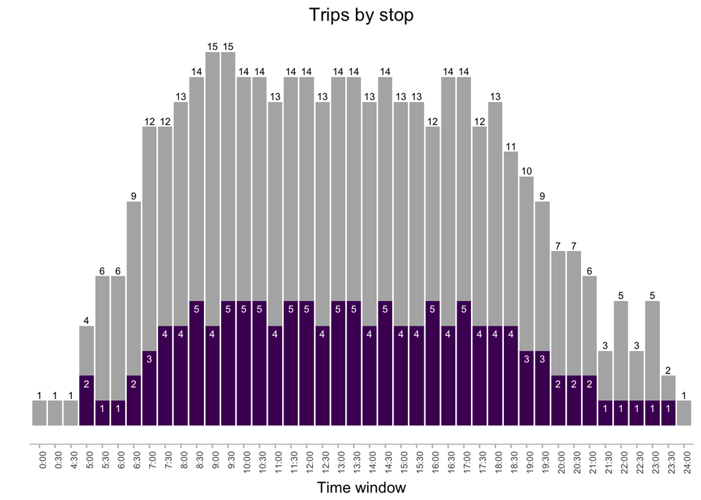

```r
g <- ggplot(data = filtered_all,
            aes(x = x_axis, y = n)) +
  geom_bar(stat = 'identity',
           alpha = 0.5) +
  geom_text(aes(label = n),
            vjust = -0.3,
            color = "black",
            size = 2.5) +
  geom_bar(data = filtered_line,
           aes(x = x_axis, y = n),
           stat = 'identity', alpha = 1,
           fill = line_color) +
  geom_text(data = filtered_line,
            aes(label = n),
            vjust = 1.6,
            color = "white",
            size = 2.5) +
  scale_fill_brewer(palette="Dark2")+
  labs(title = 'Trips by stop',
       x = "Time window",
       y = '') +
  theme(panel.grid.major = element_blank(),
        panel.grid.minor = element_blank(),
        panel.background = element_blank(),
        axis.line.x = element_line(colour = "grey"),
        axis.line.y = element_blank(),
        axis.text.x = element_text(angle = 90, hjust = 1, size = 6.5),
        axis.text.y = element_blank(),
        axis.ticks.x = element_line(colour = "grey"),
        axis.ticks.y = element_blank(),
        plot.title = element_text(hjust = 0.5)
        )
  # theme(axis.text.x = element_text(angle = 90, hjust = 1)) +
  # theme(panel.grid.major = element_blank(), panel.grid.minor = element_blank())
  # #theme(legend.position="bottom")
  #theme_minimal() +
  #theme_classic() +
  #theme_bw() +

?tiff

g
```

```r
dev.print(png, file="plot.png", width = 1500, height = 1000)
```

```r
#ggsave(png, '/Users/santiagotoso/Google Drive/Master/Curso R/GTFS/plot.png')
#png(filename = '/Users/santiagotoso/Google Drive/Master/Curso R/GTFS/plot.pdf')
#dev.print(pdf,'/Users/santiagotoso/Google Drive/Master/Curso R/GTFS/plot.pdf')
#dev.off()
```

### 1.5.2 By line

To do it by line we could start counting the number of trips that start at a given time window. For that we could keep only the stops with `stop_sequence = 1`. We could also assume that the offer is symetric and keep only the inbound trips, that means `direction_id = 0`.

```r
trips_by_line <- stop_times %>%
  filter(stop_sequence == 1 & direction_id == 0) %>%
  select(route_numeric_id, arrival_time, window_id)

trips_by_line
```

```
## # A tibble: 9,745 x 3
##    route_numeric_id arrival_time window_id
##               <int>        <dbl> <lgl>
##  1                1         4.95 NA
##  2                1         5.45 NA
##  3                1         5.85 NA
##  4                1         6.13 NA
##  5                1         6.43 NA
##  6                1         6.68 NA
##  7                1         6.93 NA
##  8                1         7.18 NA
##  9                1         7.40 NA
## 10                1         7.67 NA
## # ... with 9,735 more rows
```

We could now choose a line to try out.

```r
line <- as.integer(
  routes %>%
  filter(route_short_name == '16') %>%
  select(route_numeric_id)
  )

one_line <- trips_by_line %>%
  filter(route_numeric_id == line)

one_line
```

```
## # A tibble: 129 x 3
##    route_numeric_id arrival_time window_id
##               <int>        <dbl> <lgl>
##  1              104         5.00 NA
##  2              104         5.42 NA
##  3              104         5.92 NA
##  4              104         6.37 NA
##  5              104         6.62 NA
##  6              104         6.87 NA
##  7              104         7.12 NA
##  8              104         7.28 NA
##  9              104         7.45 NA
## 10              104         7.60 NA
## # ... with 119 more rows
```

And calculate the time window for each of the trips.

```r
for (i in 1:nrow(one_line)) {
  for (j in 1:nrow(time_windows)) {
      filtered_row <- i
      temp_time_window <- j
      #temp_stop <- stop_times[i, 'stop_numeric_id']
      temp_start <- time_windows[temp_time_window, 'starting_time']
      temp_end <- time_windows[temp_time_window,'ending_time']

      one_line[filtered_row, ] <- one_line[filtered_row, ] %>%
        #filter(is.na(time_window)) %>%
        mutate(window_id = ifelse(is.na(window_id),
                                    ifelse(arrival_time >= temp_start & arrival_time < temp_end,
                                           temp_time_window,
                                           NA),
               window_id)
        )
  }
}

head(one_line)
```

```
## # A tibble: 6 x 3
##   route_numeric_id arrival_time window_id
##              <int>        <dbl>     <int>
## 1              104         5.00        11
## 2              104         5.42        11
## 3              104         5.92        12
## 4              104         6.37        13
## 5              104         6.62        14
## 6              104         6.87        14
```

Now we could group the values by `window_id` and see how many we have for each as we did before.

```r
#For get the data for all lines
one_line_count <- one_line %>%
  select(window_id) %>%
  group_by(window_id) %>%
  count(window_id)

one_line_count
```

```
## # A tibble: 38 x 2
## # Groups:   window_id [38]
##    window_id     n
##        <int> <int>
##  1        11     2
##  2        12     1
##  3        13     1
##  4        14     2
##  5        15     3
##  6        16     4
##  7        17     4
##  8        18     5
##  9        19     5
## 10        20     5
## # ... with 28 more rows
```

```r
one_line_count <- one_line_count %>%
  left_join(time_windows) %>%
  select(x_axis, window_id, n)
one_line_count$x_axis <- factor(one_line_count$x_axis, levels = unique(one_line_count$x_axis))
```

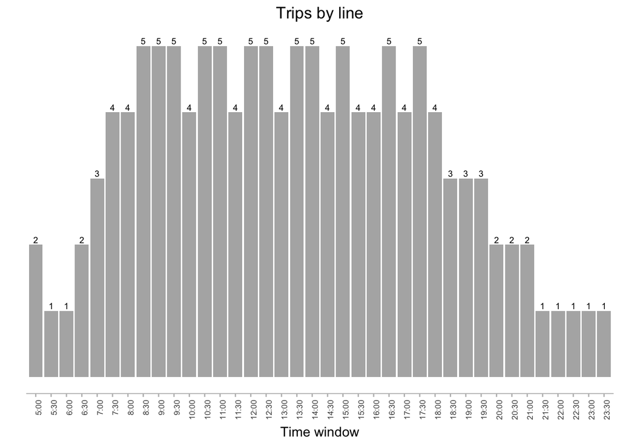

```r
g_line <- ggplot(data = one_line_count,
            aes(x = x_axis, y = n)) +
  geom_bar(stat = 'identity',
           alpha = 0.5) +
  geom_text(aes(label = n),
            vjust = -0.3,
            color = "black",
            size = 2.5) +
  scale_fill_brewer(palette="Dark2")+
  labs(title = 'Trips by line',
       x = "Time window",
       y = '') +
  theme(panel.grid.major = element_blank(),
        panel.grid.minor = element_blank(),
        panel.background = element_blank(),
        axis.line.x = element_line(colour = "grey"),
        axis.line.y = element_blank(),
        axis.text.x = element_text(angle = 90, hjust = 1, size = 6.5),
        axis.text.y = element_blank(),
        axis.ticks.x = element_line(colour = "grey"),
        axis.ticks.y = element_blank(),
        plot.title = element_text(hjust = 0.5)
        )
  # theme(axis.text.x = element_text(angle = 90, hjust = 1)) +
  # theme(panel.grid.major = element_blank(), panel.grid.minor = element_blank())
  # #theme(legend.position="bottom")
  #theme_minimal() +
  #theme_classic() +
  #theme_bw() +

?tiff

g_line
```

```r
dev.print(png, file="plot_line.png", width = 1500, height = 1000)
```

```r
#ggsave(png, '/Users/santiagotoso/Google Drive/Master/Curso R/GTFS/plot.png')
#png(filename = '/Users/santiagotoso/Google Drive/Master/Curso R/GTFS/plot.pdf')
#dev.print(pdf,'/Users/santiagotoso/Google Drive/Master/Curso R/GTFS/plot.pdf')
#dev.off()
```